# Narzędzie do porównywania talii do gry Magic the Gathering

Jan Dyszyński & Jan Grzybowski

5 listopada 2016

# Wprowadzenie

Magic the Gathering jest grą karcianą, gdzie każdy z gracy konstuuje talię z własnych kart. Ta możliwość tworzenia unikalnych zestawów uniemożliwia wskazanie jednej najlepszej talii. Na każdą taktykę znajdzie się kontrtaktyka. Dlatego naszym zadaniem było stworzenie porównywarki talii, która pomoże przewidzieć przebieg rozgrywki pomiędzy graczami, ale nie powie któa talia jest lepsza.

```r
whiteDeck <- loadDeck("whiteDeck.csv", 1)
blackDeck <- loadDeck("blackDeck.csv",2)
decks = rbind(whiteDeck, blackDeck)
```

Każdy z graczy zaczyna z 20 punktami życia i 7 losowymi kartami z talii w ręce. Celem gry jest doprowadzenie liczby punktów życia przeciwnka do zera za pomocą ataków i zdolności przyzywanych stworów oraz użytych zaklęć.

## Karty landów

Karty landów służą jako środek do płacenia za zagranie innych kart. Każdy land ma określony kolor. Obrócenie go powoduje użycie landu do zapłaty za zagranie karty. W każdej turze można dołożyć tylko jeden nowy land. Zatem koszt karty definiuje mniej więcej w której turze może zostać użyta.

[figure not shown]

## Statystyki Kart

[figure not shown]

1. Nazwa karty
2. Koszt Karty (cyfry mogą być opłacone dowolnym kolorem)
3. Typ i podtyp karty
4. Seria karty i jej rzedkość
5. Opis działania karty
6. Siła i wykrzymałość [tylko dla kart których typ to Creature]
7. Autor ilustracji

## Rozkład kolorów kart

Pierwszym sposobem na porównanie talii jest rozkład kolorów kart w talii. Jako, że poszczególne kolory mają ze sobą powiązane pewne mechaniki gry, można spodziewać na czym polegać będzie taktyka danej talii.

- Biały - dużo mniejszych tanich stworów, leczenie
- Niebieski - latające stwory, dużo zaklęć (głównie pozwalających dobrać karty lub zablkować inne zaklęcia)
- Czarny - przywracanie stworów ze stosu zużytych kart, osłabianie stworów
- Czerwony - szybkie, mało wytrzymałe, ale zadające dużo obrażeń stwory oraz zaklęcia zadające obrażenia
- Zielony - dużo drogich silnych i wytrzymałych stworów oraz zaklęcia zmniejszające ich koszt lub wzmacniające.
- Brak koloru - są to najczęściej karty artefaktów, które mogą być użyte w dowolnej talii. (dla rozróżnienia oznaczone kolorem fioletowym)

Zobaczmy zatem jakie kolory występują w naszych taliach.

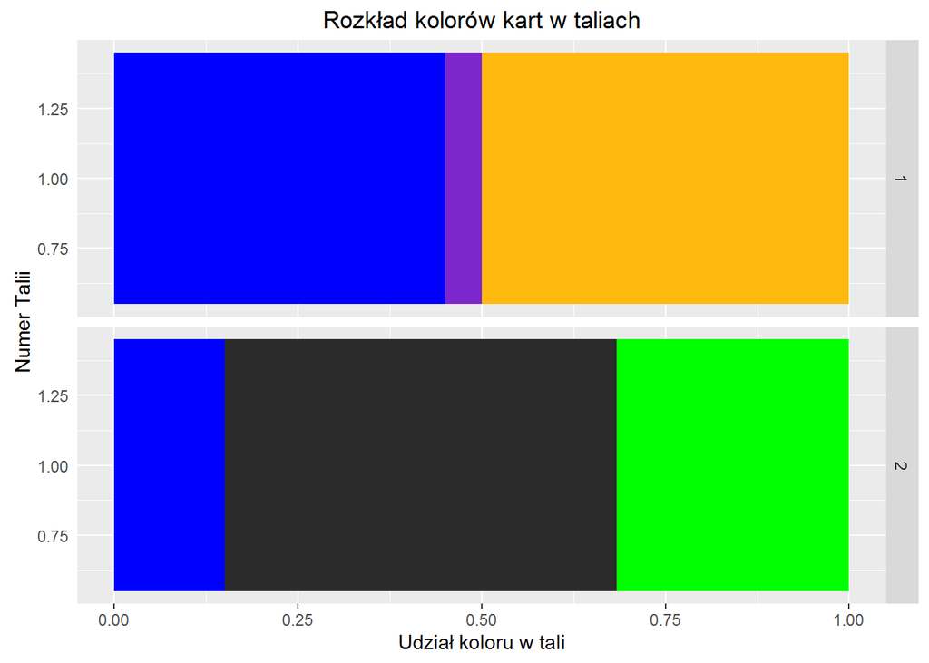

```r
ggplot(decks, aes(x=1, fill=color)) +
  scale_fill_manual(values = colorsVector) +
  geom_bar(position="fill") +
  guides(fill = FALSE) +
  coord_flip() +
  labs(x = "Numer Talii",y = "Udział koloru w tali", title = "Rozkład kolorów kart w taliach") +
  theme(axis.ticks.y=element_blank())  +
    facet_grid(deckIndex ~ .)
```

## Rozkład typów kart

Typy kart w talii są w stanie podpowiedzieć nam jakich taktyk możemy spodziewać się po naszym przeciwniku.

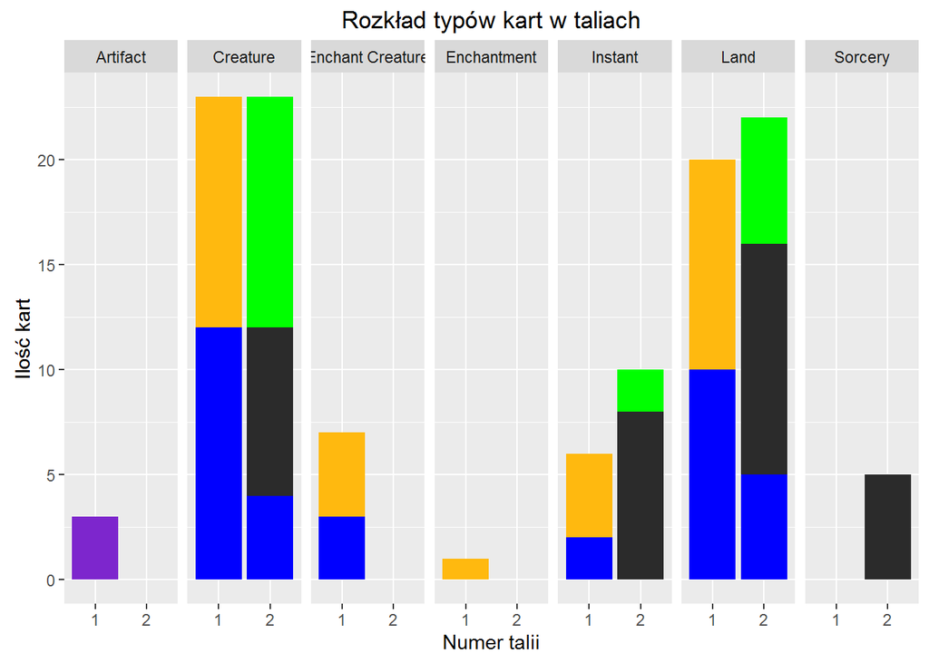

```r
ggplot(decks, aes(x=deckIndex, fill=color) ) +
    geom_bar() +
    scale_fill_manual(values = colorsVector) +
    facet_grid(. ~ type) +
    labs(x = "Numer talii", y = "Ilość kart", title = "Rozkład typów kart w taliach") +
    guides(fill = FALSE)
```

- Po graczu 1. możemy się spodziewać wystawienia stworów i wzmacniania ich za pomocą kart typu Enchant Creature.
- Po graczu 2. możemy spodziewać się droższych kart (więcej landów w talii) osłabiających gracza 1.

## Rozkład kosztów kart

Koszt karty definiuje w której turze najprawdowpodobniej będziemy mogli jej użyć oraz jak wiele kart będzie można użyć w następnych turach. Jest to czynnik pokazujący czy dana talia ma sznase na szybkie zwycięstwo czy też musi się przygotowywać do późniejszej batalii.

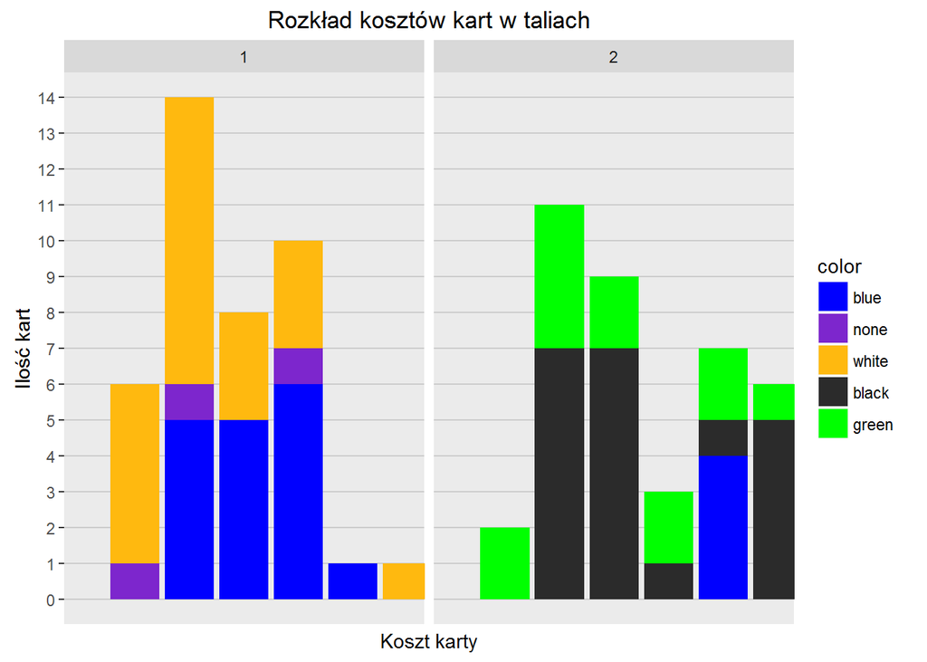

```r
maxCost = max(decks$manaCost, na.rm = T)
maxCount = max(
  max(na.omit(count(whiteDeck,manaCost))$n),
  max(na.omit(count(blackDeck,manaCost))$n)
)

ggplot(decks[!is.na(decks$manaCost),], aes(x=manaCost, fill=color)) +
    geom_bar() +
    scale_fill_manual(values = colorsVector) +
    coord_cartesian(xlim = c(0, maxCost), ylim = c(0, maxCount)) +
    scale_x_continuous(labels=0:maxCost, breaks = NULL, minor_breaks = NULL) +
    scale_y_continuous(breaks=0:maxCount, minor_breaks = NULL) +
    facet_grid(. ~ deckIndex) +
    theme(panel.grid.major = element_line(colour = "grey80")) +
    labs(x = "Koszt karty", y = "Ilość kart", title = "Rozkład kosztów kart w taliach")
```

Gracz 1. będzie dążył do szybkiego zwycięstwa za pomocą swoich stworów zanim gracz 2. nabierze wystaczająco sił, aby kontratakować.

## Przegląd statystyk stworów

Atak i obrona stworów decydują odpowiednio o tym ile mogą zadać obrażeń oraz ile ich mogą przyjąć zanim zostaną odrzucone z gry.

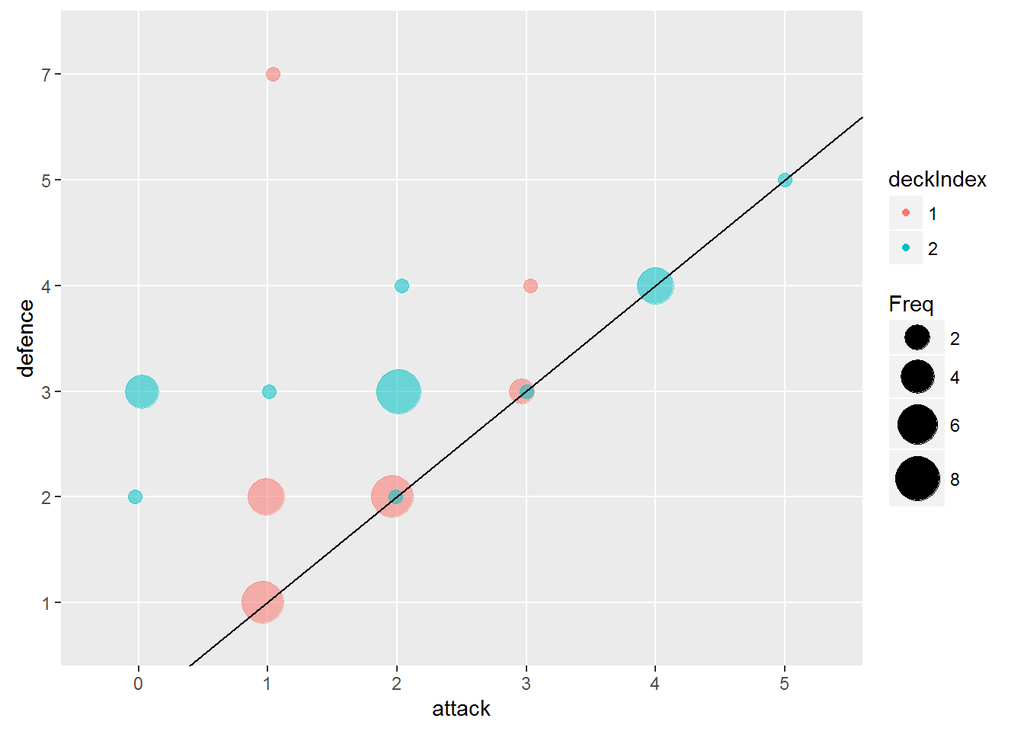

```r
  atkDef = as.data.frame(table(decks[, c("attack", "defence", "deckIndex")]))
  atkDef = atkDef[atkDef$Freq > 0,]

  p = ggplot(atkDef,aes(x=attack, y=defence, colour=deckIndex, size=Freq, alpha=0.5))
  p = p + scale_size_continuous(range = c(3,10))
  p = p + geom_point(na.rm=T, position = position_dodge(width=0.1))
  p = p + geom_abline(intercept = -1, slope = 1, colour = "black")
  p = p + guides(alpha=FALSE)
  p
```

Obie talie posiadają trochę defensywnych stworów. Jednak talia pierwszego gracza posiada też sporo uniwersalnych postaci dzięki czemu możemy założyć, że to gracz 1. będzie częściej atakował, gracz 2. będzie korzystał z zapasu wytzrzymałości swoich stworów, aby odeprzeć ataki.